# Project: Communicate Data Findings Flights

## Introduction

I have selected custom dataset for my project flights in USA in 2015. I will focus my analysis on flights in state California.

I will be answering following questions:

1. How many wheels_on passengers were travelling in California?
2. What is the rate of wheels_on flights in California?
3. Which origin airports have most wheels_on passengers on Monday in state California?
4. How many WHEELS_ON passengers flights per month were in California?

This project is divided into two major parts. In the first part, I will conduct an exploratory data analysis on a Flight USA 2015 dataset. I will conduct my analysis in Jupyter notebook using Python and its libraries. I will focus my analysis on California state. There I will look research questions above.

In the second part I will use create a slide deck with several choosen findings.

## Exploration of wheels_on passengers in California state in year 2015

I will explore flights in California state. I am also interested how many wheels_on passengers are on these flights.

### How many wheels_on passengers per month were in California?

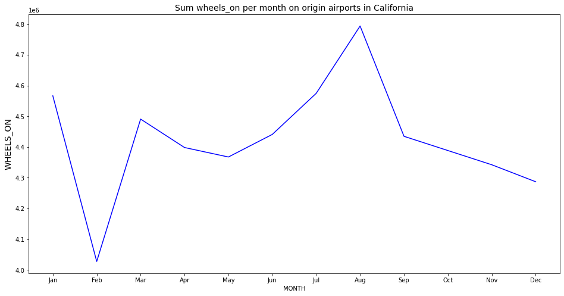

```python
airCA.groupby('MONTH')['WHEELS_ON'].sum().plot(kind = 'line', figsize = (16, 8), color = 'b')
plt.title('Sum wheels_on per month on origin airports in California', fontsize = 14 )
#plt.xlabel('MONTH', fontsize = 14)
plt.ylabel('WHEELS_ON', fontsize = 14)
width = 1
bins = np.arange(1, 14, width)
months_names = ['Jan', 'Feb', 'Mar', 'Apr', 'May', 'Jun', 'Jul', 'Aug', 'Sep', 'Oct', 'Nov', 'Dec']
plt.xticks(np.arange(1,max(bins),width), months_names);
```

We can see declination of wheels_on passengers in February - there were travelling only a little more than 4 million passengers. Highest number of wheels_on passengers was in August, there were almost 4.8 million in total.

### How many wheels_on passengers per month were in state California?

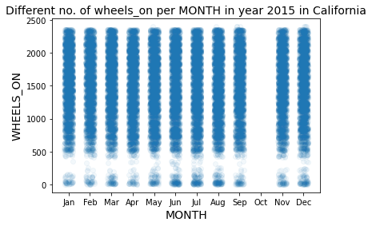

```python
sb.regplot(data = airCA, x = 'MONTH', y = 'WHEELS_ON',fit_reg = False,
          x_jitter = 0.2, y_jitter = 0.2, scatter_kws = {'alpha' : 1/20})
plt.title('Different no. of wheels_on per MONTH in year 2015 in California', fontsize = 14 )
plt.xlabel('MONTH', fontsize = 14)
plt.ylabel('WHEELS_ON', fontsize = 14);
width = 1
bins = np.arange(1, 14, width)
months_names = ['Jan', 'Feb', 'Mar', 'Apr', 'May', 'Jun', 'Jul', 'Aug', 'Sep', 'Oct', 'Nov', 'Dec']
plt.xticks(np.arange(1,max(bins),width), months_names);
```

### Which origin airports in California that have most and least wheels_on passengers in year 2015?

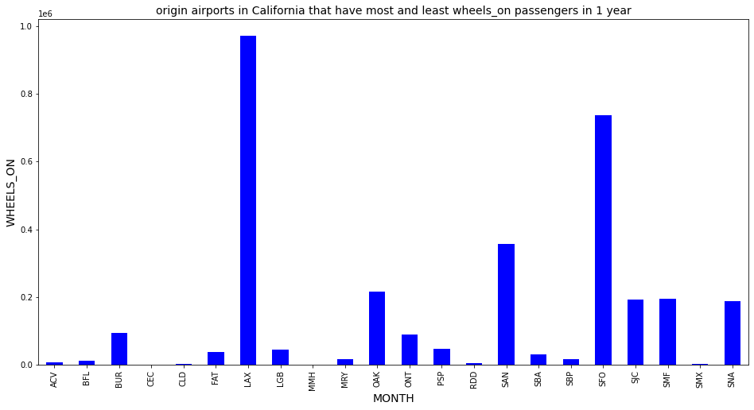

```python
#I will inspect following columns
col = ['ORIGIN_AIRPORT','MONTH', 'DAY_OF_WEEK', 'WHEELS_ON']

airCA.groupby('ORIGIN_AIRPORT')['WHEELS_ON'].sum().plot(kind = 'bar', figsize = (16, 8), color = 'b')
plt.title('origin airports in California that have most and least wheels_on passengers in 1 year', fontsize = 14 )
plt.xlabel('MONTH', fontsize = 14)
plt.ylabel('WHEELS_ON', fontsize = 14);
```